# An Introduction to dplyr

Miles Ott (with additions by Nicholas Horton)  
CVC 2017

## In order to analyze your data you need to organize your data correctly

- Keeping your data **clean** and **tidy** is an important step of every data project
- Goal: learn how to take the data set you **have** and tidy it up to be the data set you **want** for your analyses

## Tidy Data

- rows (cases/observational units) and
- columns (variables).
- The key is that *every* row is a case and *every* column is a variable.
- No exceptions.
- Wickham *Tidy Data* paper http://vita.had.co.nz/papers/tidy-data.html

## Chaining

The pipe syntax (%>%) takes a data frame (or data table) and sends it to the argument of a function.

- x %>% f(y) is the same as f(x, y)
- y %>% f(x, ., z) is the same as f(x,y,z)

## Building Tidy Data

- object_name <- function_name(arguments)
- object_name <- data_table %>% function_name(arguments)
- object_name <-  
  data_table %>%  
  function_name(arguments) %>%  
  function_name(arguments)
- in chaining, the value (on left) %>% is **first argument** to the function (on right)

## 5 Main Data Verbs

Data verbs take data tables as input and give data tables as output

1. summarise(): computes summary statistics
2. filter(): subsets unwanted *cases* (rows)
3. arrange(): reorders the *cases* (rows)
4. select(): subsets *variables* (plus `rename()` ) (columns)
5. mutate(): transforms the *variable* (and transmute() like mutate, returns only new variables) (columns)

## Other Data Verbs

- distinct(): returns the unique values in a table
- sample_n(): take random row(s)
- head(): grab the first few rows
- tail(): grab the last few rows
- group_by(): SUCCESSIVE functions are applied to groups
- ungroup(): reverse the grouping action
- summarise():
  - min(), max(), mean(), sum(), sd(), median(), and IQR()
  - n(): number of observations in the current group
  - n_distinct(): number of unique values
  - first_value(), last_value(), and nth_value(x, n): (like x[1], x[length(x)], and x[n] )

### Loading in the data

## We need to run this code to bring in the data we will use:

- First create a new `mosaic` plain template R Markdown file (File/New File/R Markdown/Template)
- Second, create a code chunk to load the `ggplot2movies` and `babynames` packages (the template already loads `mosaic`)

```r
require(mosaic)
require(ggformula)
require(ggplot2movies) #gets us movies dataset
require(babynames) #gets us baby names data set
```

### Movies data

## Example: movies data

```r
movies %>% nrow()
```

```
[1] 58788
```

```r
movies %>% names()
```

```
 [1] "title"       "year"        "length"      "budget"      "rating"
 [6] "votes"       "r1"          "r2"          "r3"          "r4"
[11] "r5"          "r6"          "r7"          "r8"          "r9"
[16] "r10"         "mpaa"        "Action"      "Animation"   "Comedy"
[21] "Drama"       "Documentary" "Romance"     "Short"
```

## Example: movies data

## 4. select() only certain variables

```r
movies %>% select(title, budget, length)
```

```
# A tibble: 58,788 x 3
                      title budget length
                      <chr>  <int>  <int>
 1                        $     NA    121
 2        $1000 a Touchdown     NA     71
 3   $21 a Day Once a Month     NA      7
 4                  $40,000     NA     70
 5 $50,000 Climax Show, The     NA     71
 6                    $pent     NA     91
 7                  $windle     NA     93
 8                     '15'     NA     25
 9                      '38     NA     97
10                  '49-'17     NA     61
# ... with 58,778 more rows
```

## Example: movies data

## 4. select() only certain variables

```r
slim_movies <- movies %>% select(title, budget, length)

slim_movies %>% names()
```

```
[1] "title"  "budget" "length"
```

- Reminder: select() is for *columns*
- Note: this is equivalent code:

```r
slim_movies <- movies %>% select(., title, budget, length)
```

## Example: movies data

```r
slim_movies %>% head()
```

```
# A tibble: 6 x 3
                     title budget length
                     <chr>  <int>  <int>
1                        $     NA    121
2        $1000 a Touchdown     NA     71
3   $21 a Day Once a Month     NA      7
4                  $40,000     NA     70
5 $50,000 Climax Show, The     NA     71
6                    $pent     NA     91
```

## Example: movies data

```r
slim_movies %>% tail()
```

```
# A tibble: 6 x 3
                    title   budget length
                    <chr>    <int>  <int>
1                  sIDney       NA     15
2               tom thumb       NA     98
3             www.XXX.com       NA    105
4  www.hellssoapopera.com       NA    100
5                     xXx 85000000    132
6 xXx: State of the Union 87000000    101
```

## Example: movies data

## Choosing random movies: using sample_n()

```r
slim_movies %>% sample_n(size = 6)
```

```
# A tibble: 6 x 3
                      title   budget length
                      <chr>    <int>  <int>
1 Eroe dei nostri tempi, Un       NA     85
2         Vsetko co mam rad       NA     99
3              Gang Busters       NA     74
4     Whistle Down the Wind       NA     99
5                White Gold       NA     91
6                  Spy Kids 35000000     88
```

## Example: movies data

## Choosing random movies: using sample_frac()

```r
slim_movies %>% sample_frac(.00007)
```

```
# A tibble: 4 x 3
               title budget length
               <chr>  <int>  <int>
1 3 Ninjas Kick Back     NA     93
2   Guns of Darkness     NA    102
3   Three Wise Fools     NA     90
4       Brother Tied     NA    109
```

Back to slim_movies data

```r
slim_movies <- slim_movies %>% filter(!is.na(budget), nchar(title) < 24)
```

## 5. mutate(): transforms the variable

mutate or transmute to create a new variable?

```r
slim_movies %>% mutate(dpm = budget/length) %>% head(6)
```

```
# A tibble: 6 x 4
               title   budget length        dpm
               <chr>    <int>  <int>      <dbl>
1            'G' Men   450000     85   5294.118
2 'Til There Was You 23000000    113 203539.823
3    .com for Murder  5000000     96  52083.333
4      100 Mile Rule  1100000     98  11224.490
5          100 Proof   140000     94   1489.362
6                101   200000    117   1709.402
```

## 5. mutate(): transforms the variable

mutate or transmute to create a new variable?

```r
slim_movies %>% transmute(dpm = budget/length) %>% head(6)
```

```
# A tibble: 6 x 1
         dpm
       <dbl>
1   5294.118
2 203539.823
3  52083.333
4  11224.490
5   1489.362
6   1709.402
```

## 1. summarise(): computes summary statistics

```r
# number of movies (cases) in movie data
movies %>% summarise(n())
```

```
# A tibble: 1 x 1
  `n()`
  <int>
1 58788
```

## 1. summarise(): computes summary statistics

```r
# total number of minutes of all the movies
movies %>% summarise(sum(length, na.rm = TRUE))
```

```
# A tibble: 1 x 1
  `sum(length, na.rm = TRUE)`
                        <int>
1                     4840479
```

## 1. summarise(): computes summary statistics

```r
# mean of minutes of all the movies
movies %>% summarise(mean(length, na.rm = TRUE))
```

```
# A tibble: 1 x 1
  `mean(length, na.rm = TRUE)`
                         <dbl>
1                     82.33788
```

## 1. summarise(): computes summary statistics

```r
# mean dollars per minute for movies with budget data
movies %>%
  mutate(dpm = budget / length) %>%
  summarise(mean(dpm, na.rm = TRUE))
```

```
# A tibble: 1 x 1
  `mean(dpm, na.rm = TRUE)`
                      <dbl>
1                  126931.7
```

## 1. summarize() with group_by()

```r
# mean length of movies in hours for all the movies, broken down by mpaa
movies %>%
  mutate(hours = length / 60) %>%
  group_by(mpaa) %>%
  summarise(mean(hours, na.rm = TRUE))
```

```
# A tibble: 5 x 2
   mpaa `mean(hours, na.rm = TRUE)`
  <chr>                       <dbl>
1                          1.344045
2 NC-17                    1.836458
3    PG                    1.623043
4 PG-13                    1.749501
5     R                    1.669500
```

## 3. arrange(): reorders the cases

```r
# average length in hours, by mpaa rating, sorted by average length
movies %>%
  mutate(hours = length / 60) %>%
  group_by(mpaa) %>%
  summarise(avelength = mean(hours, na.rm = TRUE)) %>%
  arrange(avelength)
```

```
# A tibble: 5 x 2
   mpaa avelength
  <chr>     <dbl>
1        1.344045
2    PG  1.623043
3     R  1.669500
4 PG-13  1.749501
5 NC-17  1.836458
```

### Movies: your turn

## Your Turn

When starting, it can be helpful to work with a small subset of the data. When you have your data wrangling statements in working order, shift to the entire data table.

```r
SmallSubset <-
  movies %>%
  filter(year > 2000) %>%
  filter(mpaa != "")
```

### Now it is your turn to start running the code

## Try this

## What is the average IMDB user rating?

```r
SmallSubset %>%
  summarise(avg = ????(rating))
```

## Solution

## What is the average IMDB user rating?

```r
SmallSubset %>%
  summarise(avg = mean(rating))
```

```
# A tibble: 1 x 1
       avg
     <dbl>
1 5.740306
```

## Try this

## What is the average IMDB user rating of movies for each mpaa category?

```r
SmallSubset %>%
  group_by(????) %>%
  summarise(avg = ????(rating))
```

## Solution

## What is the average rating of movies for each mpaa category?

```r
SmallSubset %>%
  group_by(mpaa) %>%
  summarise(avg = mean(rating))
```

```
# A tibble: 4 x 2
   mpaa      avg
  <chr>    <dbl>
1 NC-17 4.750000
2    PG 5.892593
3 PG-13 5.903524
4     R 5.655228
```

## Try this

## How many Action Movies in each year?

```r
SmallSubset %>%
  group_by(????) %>%
  summarise(Actioncount = sum(????))
```

## Solution

## How many Action Movies in each year?

```r
SmallSubset %>%
  group_by(year) %>%
  summarise(Actioncount = sum(Action))
```

```
# A tibble: 5 x 2
   year Actioncount
  <int>       <int>
1  2001          94
2  2002          95
3  2003          82
4  2004          60
5  2005          18
```

## Try this

## How many Comedies of each mpaa rating in each year?

```r
SmallSubset %>%
  group_by(????, ????) %>%
  summarise(????)
```

## Solution

## How many Comedies of each mpaa rating in each year?

```r
SmallSubset %>%
  group_by(year, mpaa) %>%
  summarise(ComedyCount = sum(Comedy))
```

```
# A tibble: 17 x 3
# Groups:   year [?]
    year  mpaa ComedyCount
   <int> <chr>       <int>
 1  2001 NC-17           0
 2  2001    PG          27
 3  2001 PG-13          53
 4  2001     R         107
 5  2002    PG          22
 6  2002 PG-13          50
 7  2002     R          95
 8  2003    PG          27
 9  2003 PG-13          56
10  2003     R          67
11  2004    PG          25
12  2004 PG-13          46
13  2004     R          59
14  2005 NC-17           0
15  2005    PG           9
16  2005 PG-13          14
17  2005     R           3
```

## Try this

## Track the average IMDB ratings for movies with mpaa “R” over the years.

```r
RMovies <-
  movies %>%
  filter(mpaa == "R") %>%      # just the rated R movies
  group_by(????) %>% # for each year for each movie title
  summarise(mean_user_rating = ????)
```

## Solution

## Track the average IMDB ratings for movies with mpaa “R” over the years.

```r
RMovies <-
  movies %>%
  filter(mpaa == "R") %>% # just the rated R movies
  group_by(year) %>% # for each year for each movie title
  summarise(mean_user_rating = mean(rating))
```

## Try This Plot out the result

```r
gf_line(???? ~ ????, data = RMovies)
```

## Solution Plot out the result

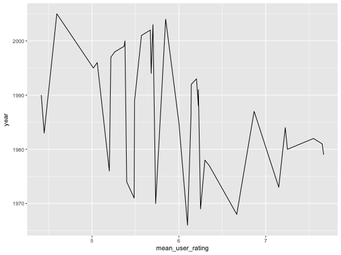

```r
gf_line(year ~ mean_user_rating, data = RMovies)
```

## Before we explore the babynames data let's remind ourselves of the dplyr commands we have learned thus far:

### 5 Main Data Verbs

## 5 Main Data Verbs

Data verbs take data tables as input and give data tables as output

1. summarise(): computes summary statistics
2. filter(): subsets unwanted *cases*
3. arrange(): reorders the *cases*
4. select(): subsets *variables* (and rename() )
5. mutate(): transforms the *variable* (and transmute() like mutate, returns only new variables)

## Other Data Verbs

- distinct(): returns the unique values in a table
- sample_n(): take random row(s)
- head(): grab the first few rows
- tail(): grab the last few rows
- group_by(): SUCCESSIVE functions are applied to groups
- ungroup(): reverse the grouping action
- summarise():
  - min(), max(), mean(), sum(), sd(), median(), and IQR()
  - n(): number of observations in the current group
  - n_distinct(): number of unique values
  - first_value(), last_value(), and nth_value(x, n): (like x[1], x[length(x)], and x[n] )

### Babynames dataset

```r
babynames %>% names()
```

```
[1] "year" "sex"  "name" "n"    "prop"
```

```r
babynames %>% head()
```

```
# A tibble: 6 x 5
   year   sex      name     n       prop
  <dbl> <chr>     <chr> <int>      <dbl>
1  1880     F      Mary  7065 0.07238433
2  1880     F      Anna  2604 0.02667923
3  1880     F      Emma  2003 0.02052170
4  1880     F Elizabeth  1939 0.01986599
5  1880     F    Minnie  1746 0.01788861
6  1880     F  Margaret  1578 0.01616737
```

### Babynames dataset

```r
babynames %>% glimpse()
```

```
Observations: 1,858,689
Variables: 5
$ year <dbl> 1880, 1880, 1880, 1880, 1880, 1880, 1880, 1880, 1880, 188...
$ sex  <chr> "F", "F", "F", "F", "F", "F", "F", "F", "F", "F", "F", "F...
$ name <chr> "Mary", "Anna", "Emma", "Elizabeth", "Minnie", "Margaret"...
$ n    <int> 7065, 2604, 2003, 1939, 1746, 1578, 1472, 1414, 1320, 128...
$ prop <dbl> 0.072384329, 0.026679234, 0.020521700, 0.019865989, 0.017...
```

### Babynames dataset

```r
babynames %>% inspect()
```

```
categorical variables:
  name     class levels       n missing
1  sex character      2 1858689       0
2 name character  95025 1858689       0
                                   distribution
1 F (59.2%), M (40.8%)
2 Francis (0%), James (0%) ...

quantitative variables:
  name   class          min           Q1       median           Q3
1 year numeric 1.880000e+03 1.950000e+03 1.983000e+03 2.002000e+03
2    n integer 5.000000e+00 7.000000e+00 1.200000e+01 3.200000e+01
3 prop numeric 2.259872e-06 3.900959e-06 7.348183e-06 2.324258e-05
          max         mean           sd       n missing
1 2.01500e+03 1.973376e+03   33.6978783 1858689       0
2 9.96800e+04 1.833830e+02 1555.3570871 1858689       0
3 8.15463e-02 1.391443e-04    0.0011702 1858689       0
```

Note: `prop` differs from what you think it might be.

## Your Turn

Again let's work with a small subset of the data.

```r
set.seed(1999)
smallbaby <-
  babynames %>%
  filter(year > 2000) %>%
  sample_n(size = 300)

names(smallbaby)
```

```
[1] "year" "sex"  "name" "n"    "prop"
```

## Try this

## How many babies are represented?

```r
smallbaby %>%
  summarise(total = ????(n)) # a reduction verb
```

## Solution

## How many babies are represented?

```r
smallbaby %>%
  summarise(total = sum(n))
```

```
# A tibble: 1 x 1
  total
  <int>
1 19580
```

## Try this

## How many babies are there in each year?

```r
smallbaby %>%
  group_by(????) %>%
  summarise(total = ????(n))
```

## Solution

## How many babies are there in each year?

```r
smallbaby %>%
  group_by(year) %>%
  summarise(total = sum(n))
```

```
# A tibble: 15 x 2
    year total
   <dbl> <int>
 1  2001   671
 2  2002  1401
 3  2003   237
 4  2004   431
 5  2005   669
 6  2006   314
 7  2007  1422
 8  2008  1352
 9  2009  1901
10  2010   541
11  2011  6733
12  2012  1627
13  2013   438
14  2014  1150
15  2015   693
```

## Try this

## How many distinct names in each year?

```r
smallbaby %>%
  group_by(????) %>%
  summarise(name_count = n_distinct(????))
```

## Solution

## How many distinct names in each year?

```r
smallbaby %>%
  group_by(year) %>%
  summarise(name_count = n_distinct(name), num = n())  # equivalent to n() here
```

```
# A tibble: 15 x 3
    year name_count   num
   <dbl>      <int> <int>
 1  2001         10    10
 2  2002         13    13
 3  2003         10    10
 4  2004         16    16
 5  2005         12    12
 6  2006         19    19
 7  2007         30    30
 8  2008         25    25
 9  2009         28    28
10  2010         17    17
11  2011         23    23
12  2012         26    26
13  2013         23    23
14  2014         21    21
15  2015         27    27
```

## Try this

## How many distinct names of each sex?

```r
smallbaby %>%
  group_by(????, ????) %>%
  summarise(????)
```

## Solution

## How many distinct names of each sex?

```r
temp <- smallbaby %>%
  group_by(sex) %>%
  summarise(name_count = n_distinct(name), num = n())  # not equivalent
data.frame(temp)
```

```
  sex name_count num
1   F        189 190
2   M        110 110
```

## Reminder filter(): subsets *cases* (rows)

subset for babies named Nicholas

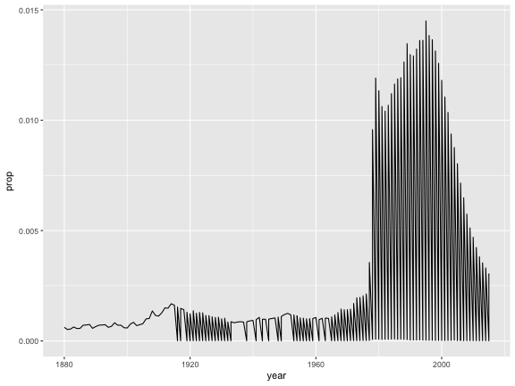

```r
nicknames <- babynames %>% filter(name == "Nicholas")

gf_line(prop ~ year, data = nicknames)
```

## That looked weird…

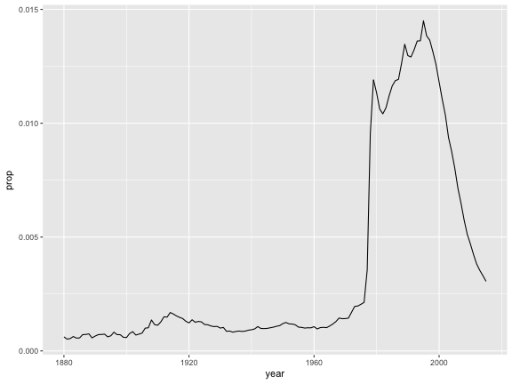

```r
nicknames_male <- babynames %>% filter(name == "Nicholas", sex == "M")

gf_line(prop ~ year, data = nicknames_male)
```

## Try this

### More than one name

### Track the yearly number of Janes and Marys over the years. Use the full dataset

```r
MaryJane <-
  babynames %>%
  ????(name %in% c("Jane", "Mary")) %>% # just the Janes and Marys
  group_by(????, ????) %>% # for each year for each name
  summarise(count = ????)
```

### Jane and Mary

## Solution

### More than one name

### Track the yearly number of Janes and Marys over the years. Use the full dataset

```r
MaryJane <-
  babynames %>%
  filter(name %in% c("Jane", "Mary")) %>% # just the Janes and Marys
  group_by(name, year) %>% # for each year for each name
  summarise(count = sum(n))
```

## Plot out the result

### Put `year` on the x-axis and the count of each name on the y-axis.

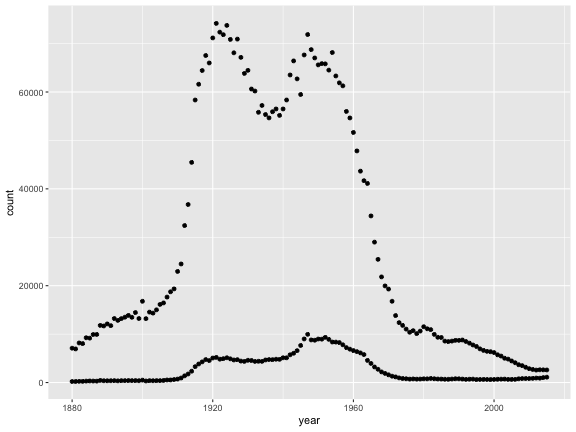

```r
gf_point(count ~ year, data = MaryJane)
```

## Try this

- *Map* the name (Mary or Jane) to the color aesthetic
- Instead of using dots as the glyph, use a line that connects consecutive values: `gf_line()`.
- *Set* the line thickness to 2.

### Plot out the result

```r
gf_line(???? ~ ????, color = ????, size = ????, data = MaryJane)
```

## Solution

### Plot out the result

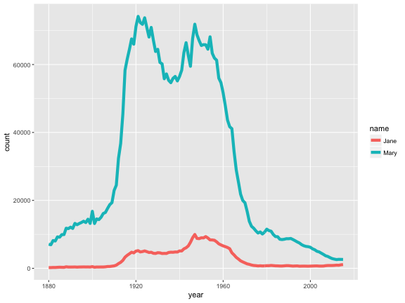

```r
gf_line(count ~ year, color = ~ name, size = 2, data = MaryJane)
```

## Try this

### Look at the *proportion* of births rather than the count

Filter first on female, then on Mary and Jane. Meanwhile, calculate the proportion of names in the dataset which are Mary and Jane (as opposed to the proportion of all babies from the given year which is the *prop* variable).

```r
Result2 <-
  babynames %>%
  filter(sex == "F") %>%
  group_by(year) %>%
  mutate(total = ????(n)) %>%
  filter(????) %>%
  mutate(proportion = n / total)
```

## Solution

### Look at the *proportion* of births rather than the count

```r
Result2 <-
  babynames %>%
  filter(sex == "F") %>%
  group_by(year) %>%
  mutate(total = sum(n)) %>%
  filter(name %in% c("Mary", "Jane")) %>%
  mutate(proportion = n / total)
```

## Try this

### Plot a line graph of the proportion of babies named Mary and Jane over the years with separate different colored lines for Mary and Jane

```r
gf_line(???? ~ ????, color = ????, data = Result2)
```

## Solution

## Plot a line graph of the proportion of babies named Mary and Jane over the years with separate different colored lines for Mary and Jane

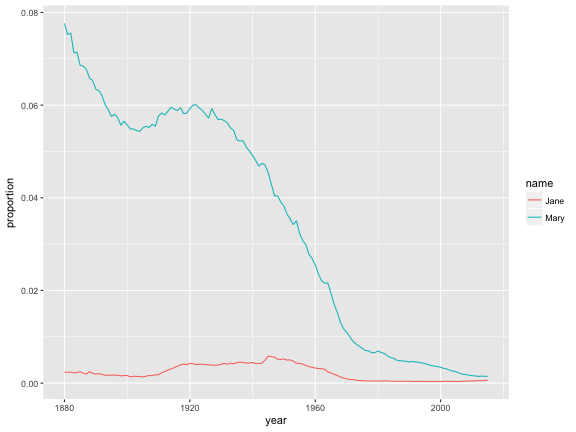

```r
gf_line(proportion ~ year, color = ~ name, data = Result2)
```

## Pick out name(s) of interest to you

### Plot out their popularity over time.

### I want to find out if the name Pat was ever more common for males than females

```r
Pat <- babynames %>%
  filter(name == "Pat")
```

## Pick out name(s) of interest to you

### Plot out their popularity over time.

### I want to find out if the name Pat was ever more common for males than females

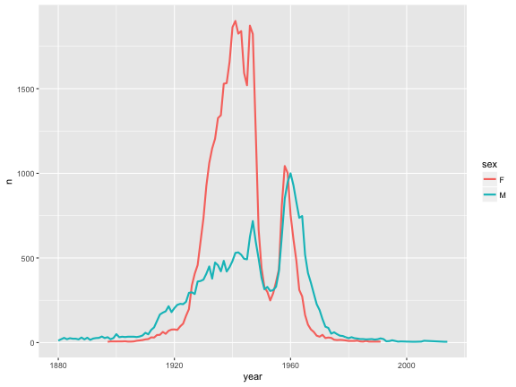

```r
gf_line(n ~ year, col = ~ sex, size = 1, data = Pat)
```

# You are on your way to wrangling and transforming your data with ease

## Keep practicing, keep learning

[figure not shown]